# Ensemble methods

# Introduction

Today, we will learn how to use different ensemble methods in `R`, recap on how to evaluate the performance of the methods, and learn how we can substantively interpret the model output.

In this practical we will work with the ILPD (Indian Liver Patient Dataset) from the UCI Machine Learning Repository (you can find the data here). This data set contains data on 414 liver disease patients, and 165 non-patients. In general, medical researchers have two distinct goals when doing research: (1) to be able to classify people in their waiting room as either patients or non-patients, and (2) get insight into the factors that are associated with the disease. In this practical, we will look at both aspects.

In this practical, we will use the `tidyverse`, `magrittr`, `psych`, `GGally` and `caret` libraries.

```r
library(tidyverse)
library(magrittr)
library(psych)
library(caret)
library(gbm)
library(xgboost)
library(data.table)
library(ggforce)
```

First, we specify a seed and load the training data. We will use this data to make inferences and to train a prediction model.

```r
set.seed(45)
df <- readRDS("data/train_disease.RDS")
```

**1. Get an impression of the data by looking at the structure of the data and creating some descriptive statistics.**

```r
head(df)
```

| Age | Gender | Total_Bilirubin | Direct_Bilirubin | Alkaline_Phosphotase | Alamine_Aminotransferase | Aspartate_Aminotransferase | Total_Protiens | Albumin | Ratio_Albumin_Globulin | Disease |
| --- | --- | --- | --- | --- | --- | --- | --- | --- | --- | --- |
| 58 | Female | 1.7 | 0.8 | 1896 | 61 | 83 | 8.0 | 3.9 | 0.95 | Healthy |
| 56 | Male | 1.0 | 0.3 | 195 | 22 | 28 | 5.8 | 2.6 | 0.80 | Disease |
| 35 | Male | 2.0 | 1.1 | 226 | 33 | 135 | 6.0 | 2.7 | 0.80 | Disease |
| 51 | Female | 0.9 | 0.2 | 280 | 21 | 30 | 6.7 | 3.2 | 0.80 | Healthy |
| 21 | Male | 18.5 | 9.5 | 380 | 390 | 500 | 8.2 | 4.1 | 1.00 | Healthy |
| 60 | Male | 3.2 | 1.8 | 750 | 79 | 145 | 7.8 | 3.2 | 0.69 | Healthy |

```r
tail(df)
```

| Age | Gender | Total_Bilirubin | Direct_Bilirubin | Alkaline_Phosphotase | Alamine_Aminotransferase | Aspartate_Aminotransferase | Total_Protiens | Albumin | Ratio_Albumin_Globulin | Disease |
| --- | --- | --- | --- | --- | --- | --- | --- | --- | --- | --- |
| 45 | Male | 0.8 | 0.2 | 140 | 24 | 20 | 6.3 | 3.2 | 1.00 | Disease |
| 48 | Female | 1.4 | 0.8 | 621 | 110 | 176 | 7.2 | 3.9 | 1.10 | Healthy |
| 17 | Male | 0.9 | 0.3 | 202 | 22 | 19 | 7.4 | 4.1 | 1.20 | Disease |
| 38 | Male | 0.8 | 0.2 | 247 | 55 | 92 | 7.4 | 4.3 | 1.38 | Disease |
| 42 | Male | 16.4 | 8.9 | 245 | 56 | 87 | 5.4 | 2.0 | 0.50 | Healthy |
| 37 | Male | 1.3 | 0.4 | 195 | 41 | 38 | 5.3 | 2.1 | 0.60 | Healthy |

```r
df %>%
  select(-c(Gender, Disease)) %>%
  describeBy(df$Disease, fast = TRUE)
```

```
##
##  Descriptive statistics by group
## group: Healthy
##                            vars   n   mean     sd  min    max  range    se
## Age                           1 360  45.81  15.60 10.0   90.0   80.0  0.82
## Total_Bilirubin               2 360   4.05   7.15  0.4   75.0   74.6  0.38
## Direct_Bilirubin              3 360   1.86   3.16  0.1   19.7   19.6  0.17
## Alkaline_Phosphotase          4 360 309.47 250.37 63.0 2110.0 2047.0 13.20
## Alamine_Aminotransferase      5 360  97.19 200.17 12.0 1680.0 1668.0 10.55
## Aspartate_Aminotransferase    6 360 133.66 324.59 11.0 4929.0 4918.0 17.11
## Total_Protiens                7 360   6.47   1.11  2.7    9.6    6.9  0.06
## Albumin                       8 360   3.07   0.80  0.9    5.5    4.6  0.04
## Ratio_Albumin_Globulin        9 360   0.92   0.32  0.3    2.8    2.5  0.02
## ------------------------------------------------------------
## group: Disease
##                            vars   n   mean     sd   min    max   range    se
## Age                           1 140  41.51  16.98  4.00   85.0   81.00  1.43
## Total_Bilirubin               2 140   1.14   1.01  0.50    7.3    6.80  0.09
## Direct_Bilirubin              3 140   0.40   0.53  0.10    3.6    3.50  0.04
## Alkaline_Phosphotase          4 140 220.56 149.76 90.00 1580.0 1490.00 12.66
## Alamine_Aminotransferase      5 140  33.31  24.50 10.00  181.0  171.00  2.07
## Aspartate_Aminotransferase    6 140  39.79  34.79 10.00  285.0  275.00  2.94
## Total_Protiens                7 140   6.53   1.07  3.70    9.2    5.50  0.09
## Albumin                       8 140   3.34   0.80  1.40    5.0    3.60  0.07
## Ratio_Albumin_Globulin        9 140   1.04   0.30  0.37    1.9    1.53  0.03
```

```r
# It becomes directly clear that there are substantial differences between
# the diseased and non-diseased in the data.
```

**2. To further explore the data we work with, create some interesting data visualizations that show whether there are interesting patterns in the data.**

*Hint:* Think about adding a color aesthetic for the variable `Disease`.

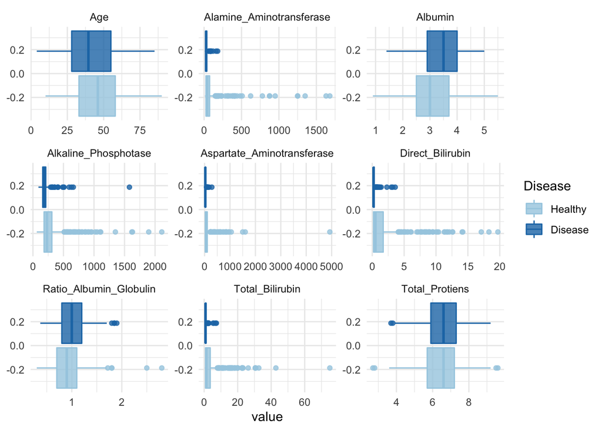

```r
df %>%
  select(-Gender) %>%
  pivot_longer(where(is.numeric)) %>%
  ggplot(aes(x = value, col = Disease, fill = Disease)) +
  geom_boxplot(alpha = 0.8) +
  facet_wrap(~name, scales = "free") +
  scale_color_brewer(palette = "Paired") +
  scale_fill_brewer(palette = "Paired") +
  theme_minimal()
```

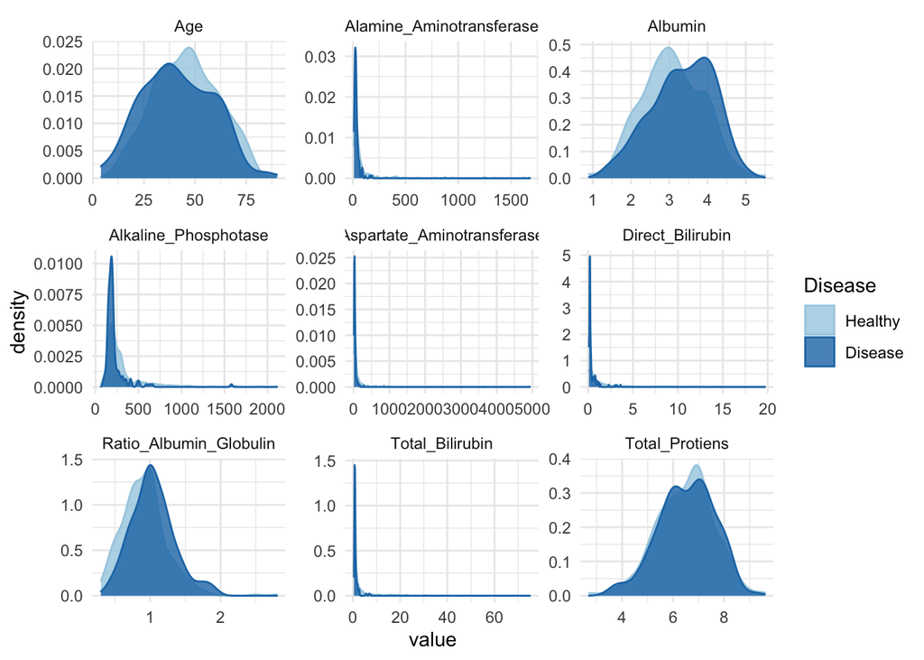

```r
df %>%
  select(-Gender) %>%
  pivot_longer(where(is.numeric)) %>%
  ggplot(aes(x = value, col = Disease, fill = Disease)) +
  geom_density(alpha = 0.8) +
  facet_wrap(~name, scales = "free") +
  scale_color_brewer(palette = "Paired") +
  scale_fill_brewer(palette = "Paired") +
  theme_minimal()
```